# Case Study 1 - Cyclistic

Dan Moriarty

2022-07-09

This is my first case study. It is from the Google Data Analytics Professional Certificate course. The course covers Excel, SQL, Tableau, and R. I chose to complete this case study in R as it offered a similar process to my experience with C# and Ruby. I was also interested in the combination of analytical tools and visualization capabilities.

## Scenario

In this scenario I am a junior data analyst working on the marketing analyst team at Cyclistic, a bike-share company in Chicago. The marketing director believes future success depends on maximizing annual memberships.

### Ask

Business Task: Determine how annual members and casual riders use Cyclistic bikes differently, for the purpose of designing a new marketing strategy to convert casual riders into annual members.

### Prepare

This analysis was based off the data set found [here](https://divvy-tripdata.s3.amazonaws.com/index.html).

The data was made available by Motivate International Inc. under [this license](https://www.divvybikes.com/data-license-agreement) .

(Note: The data sets have a different name because Cyclistic is a fictional company.)

### Process

Once I had the data, I needed to clean it and prepare it for analysis. The first step was to see what I was working with.

Below is a summary of the raw data from June of 2021.

```
##    ride_id          rideable_type        started_at
##  Length:729595      Length:729595      Min.   :2021-06-01 00:00:38.00
##  Class :character   Class :character   1st Qu.:2021-06-08 16:03:57.00
##  Mode  :character   Mode  :character   Median :2021-06-14 19:46:47.00
##                                        Mean   :2021-06-15 09:48:47.76
##                                        3rd Qu.:2021-06-21 19:10:47.00
##                                        Max.   :2021-06-30 23:59:59.00
##
##     ended_at                      start_station_name start_station_id
##  Min.   :2021-06-01 00:06:22.00   Length:729595      Length:729595
##  1st Qu.:2021-06-08 16:23:54.00   Class :character   Class :character
##  Median :2021-06-14 20:13:55.00   Mode  :character   Mode  :character
##  Mean   :2021-06-15 10:14:52.60
##  3rd Qu.:2021-06-21 19:31:59.00
##  Max.   :2021-07-13 22:51:35.00
##
##  end_station_name   end_station_id       start_lat       start_lng
##  Length:729595      Length:729595      Min.   :41.64   Min.   :-87.78
##  Class :character   Class :character   1st Qu.:41.88   1st Qu.:-87.66
##  Mode  :character   Mode  :character   Median :41.90   Median :-87.64
##                                        Mean   :41.90   Mean   :-87.64
##                                        3rd Qu.:41.93   3rd Qu.:-87.63
##                                        Max.   :42.07   Max.   :-87.52
##
##     end_lat         end_lng       member_casual
##  Min.   :41.51   Min.   :-87.86   Length:729595
##  1st Qu.:41.88   1st Qu.:-87.66   Class :character
##  Median :41.90   Median :-87.64   Mode  :character
##  Mean   :41.90   Mean   :-87.64
##  3rd Qu.:41.93   3rd Qu.:-87.63
##  Max.   :42.08   Max.   :-87.49
##  NA's   :717     NA's   :717
```

Next I needed to clean the data, which included the steps below.

- Creating a duplicate data set to preserve the original data.
- Cleaning the column names of formatting errors and extra whitespace.
- Removing duplicate data based on ride id.
- Removing incomplete data.
- Removing data with a negative trip duration.
- Removing trip duration outliers.

Once the data was clean, I manipulated it to add trip duration, day of the week, and month information. With each data set clean and uniform, I merged them in to one data set containing all twelve months of data.

#### Summary of cleaned and processed Data

```
##    ride_id          rideable_type        started_at
##  Length:4310606     Length:4310606     Min.   :2021-06-01 00:00:38.00
##  Class :character   Class :character   1st Qu.:2021-07-26 17:54:17.75
##  Mode  :character   Mode  :character   Median :2021-09-17 17:53:35.50
##                                        Mean   :2021-10-22 06:53:50.22
##                                        3rd Qu.:2021-12-30 16:33:07.50
##                                        Max.   :2022-05-31 23:59:56.00
##     ended_at                      start_station_name start_station_id
##  Min.   :2021-06-01 00:08:19.00   Length:4310606     Length:4310606
##  1st Qu.:2021-07-26 18:08:48.25   Class :character   Class :character
##  Median :2021-09-17 18:08:47.00   Mode  :character   Mode  :character
##  Mean   :2021-10-22 07:07:07.58
##  3rd Qu.:2021-12-30 16:43:24.50
##  Max.   :2022-06-01 00:31:41.00
##  end_station_name   end_station_id       start_lat       start_lng
##  Length:4310606     Length:4310606     Min.   :41.65   Min.   :-87.83
##  Class :character   Class :character   1st Qu.:41.88   1st Qu.:-87.66
##  Mode  :character   Mode  :character   Median :41.90   Median :-87.64
##                                        Mean   :41.90   Mean   :-87.64
##                                        3rd Qu.:41.93   3rd Qu.:-87.63
##                                        Max.   :45.64   Max.   :-73.80
##     end_lat         end_lng       member_casual      trip_duration_sec
##  Min.   :41.65   Min.   :-87.83   Length:4310606     Length:4310606
##  1st Qu.:41.88   1st Qu.:-87.66   Class :character   Class :difftime
##  Median :41.90   Median :-87.64   Mode  :character   Mode  :numeric
##  Mean   :41.90   Mean   :-87.64
##  3rd Qu.:41.93   3rd Qu.:-87.63
##  Max.   :42.07   Max.   :-87.53
##  trip_duration_min                day_of_week    trip_duration_numeric
##  Min.   :1S                      Min.   :1.000   Min.   :   1.0
##  1st Qu.:6M 16S                  1st Qu.:2.000   1st Qu.: 376.0
##  Median :10M 42S                 Median :4.000   Median : 642.0
##  Mean   :13M 17.3652518926598S   Mean   :4.085   Mean   : 797.4
##  3rd Qu.:17M 58S                 3rd Qu.:6.000   3rd Qu.:1078.0
##  Max.   :49M 43S                 Max.   :7.000   Max.   :2983.0
```

A quick look at the cleaned and processed data revealed that the average trip duration across all riders was a little over 13 minutes. There was a difference of just 11 minutes between the first and third quartile time. From this information, I inferred that the majority of trips are of short to moderate length.

One interesting observation that came up during cleaning was the extreme length of a few trip duration outliers. Note the max time of 38 days under the trip_duration_min column below.

```
##    ride_id          rideable_type        started_at
##  Length:608763      Length:608763      Min.   :2021-06-01 00:00:38.00
##  Class :character   Class :character   1st Qu.:2021-06-08 15:59:25.00
##  Mode  :character   Mode  :character   Median :2021-06-14 19:23:06.00
##                                        Mean   :2021-06-15 09:07:17.98
##                                        3rd Qu.:2021-06-21 17:58:51.00
##                                        Max.   :2021-06-30 23:59:59.00
##     ended_at                      start_station_name start_station_id
##  Min.   :2021-06-01 00:08:19.00   Length:608763      Length:608763
##  1st Qu.:2021-06-08 16:21:43.50   Class :character   Class :character
##  Median :2021-06-14 19:48:25.00   Mode  :character   Mode  :character
##  Mean   :2021-06-15 09:33:37.31
##  3rd Qu.:2021-06-21 18:18:23.00
##  Max.   :2021-07-13 22:51:35.00
##  end_station_name   end_station_id       start_lat       start_lng
##  Length:608763      Length:608763      Min.   :41.65   Min.   :-87.77
##  Class :character   Class :character   1st Qu.:41.88   1st Qu.:-87.65
##  Mode  :character   Mode  :character   Median :41.90   Median :-87.64
##                                        Mean   :41.90   Mean   :-87.64
##                                        3rd Qu.:41.93   3rd Qu.:-87.63
##                                        Max.   :42.06   Max.   :-87.53
##     end_lat         end_lng       member_casual      trip_duration_sec
##  Min.   :41.65   Min.   :-87.77   Length:608763      Length:608763
##  1st Qu.:41.88   1st Qu.:-87.65   Class :character   Class :difftime
##  Median :41.90   Median :-87.64   Mode  :character   Mode  :numeric
##  Mean   :41.90   Mean   :-87.64
##  3rd Qu.:41.93   3rd Qu.:-87.63
##  Max.   :42.08   Max.   :-87.53
##  trip_duration_min                day_of_week    trip_duration_numeric
##  Min.   :1S                      Min.   :1.000   Min.   :      1
##  1st Qu.:7M 48S                  1st Qu.:2.000   1st Qu.:    468
##  Median :13M 43S                 Median :4.000   Median :    823
##  Mean   :26M 19.3357546368604S   Mean   :4.173   Mean   :   1579
##  3rd Qu.:24M 34S                 3rd Qu.:6.000   3rd Qu.:   1474
##  Max.   :38d 20H 24M 9S          Max.   :7.000   Max.   :3356649
```

### Analyze & Share

#### Monthly Trips

To start my analysis I wanted to look at the big picture. I decided to first review the monthly use of Cyclistic bikes by both members and casual riders. I plotted out the number of rides per month for both groups and found members tended to use bikes at a higher rate over a wider range of months. There was also a marked difference in casual and member ridership during the winter months, with members using Cyclistic bikes significantly more often.

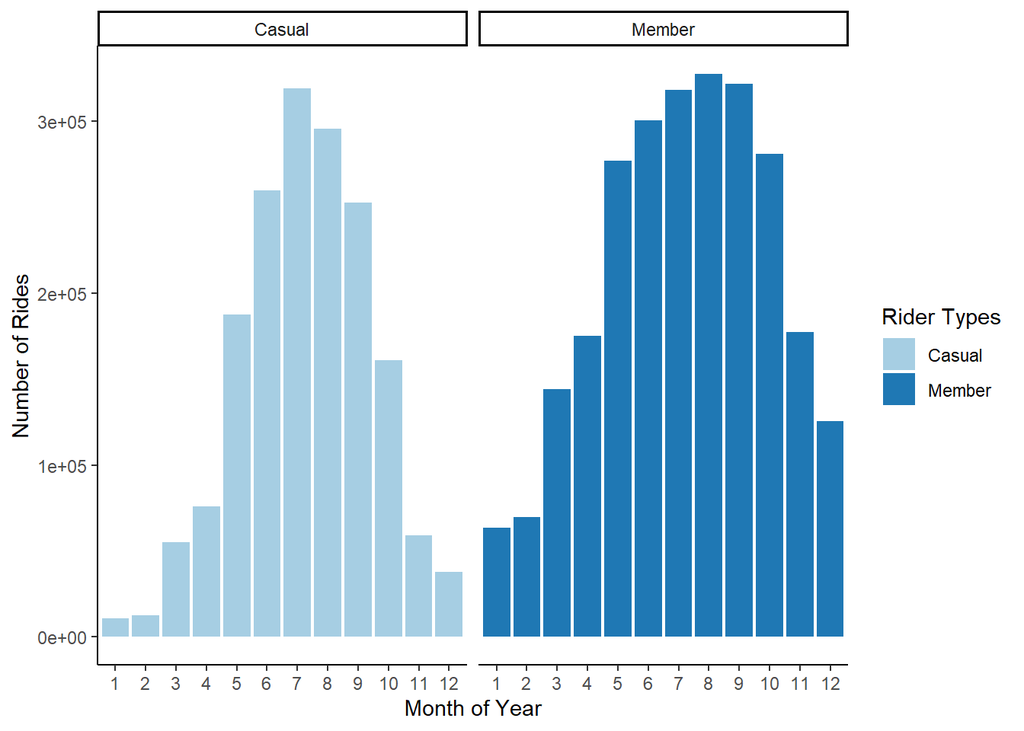

#### Hourly Trips

With this information in mind, the next data I dug in to was the number of rides taken on an hourly basis each day. I wanted to see what the difference was in daily ridership between casual and member riders. I also wanted to get an idea for what time of day was most popular with each group.

Having segmented the data by hour, it became possible to see users riding trends and how the two rider types compared in their daily usage.

The first observation involved bike use by both groups on weekdays. The Monday through Friday charts indicated the most popular time to start a ride for both groups was at the end of the work day, peaking around 5pm. The second most popular time for members was at the beginning of the work day, around 8am. Interestingly, casual riders didn’t show a second peak throughout the day. Instead they increased from 5am until 5pm, then steadily declined until 5am the next day.

The weekend charts were very different. Ridership started to pick up around 6am and continued to rise until 11am. At that point it remained around the same level until 5 or 6pm, when it started to taper back down. On both Saturdays and Sundays member and casual ridership was very similar, with casual ridership actually overtaking member ridership during the late evening/early morning hours.

From this information I estimated that member riders are more likely to use their rides to get to and from work. This is true for some casual members as well, but it seems they are more prone to taking a bike for just the return trip. The weekends are when most casual rides happen, and the increase in late night and mid day use indicated to me a leisure or convenience oriented use-case for most casual riders.

Note: Plots with multiple multi-colored bars indicate data that is stacked, not overlapping.

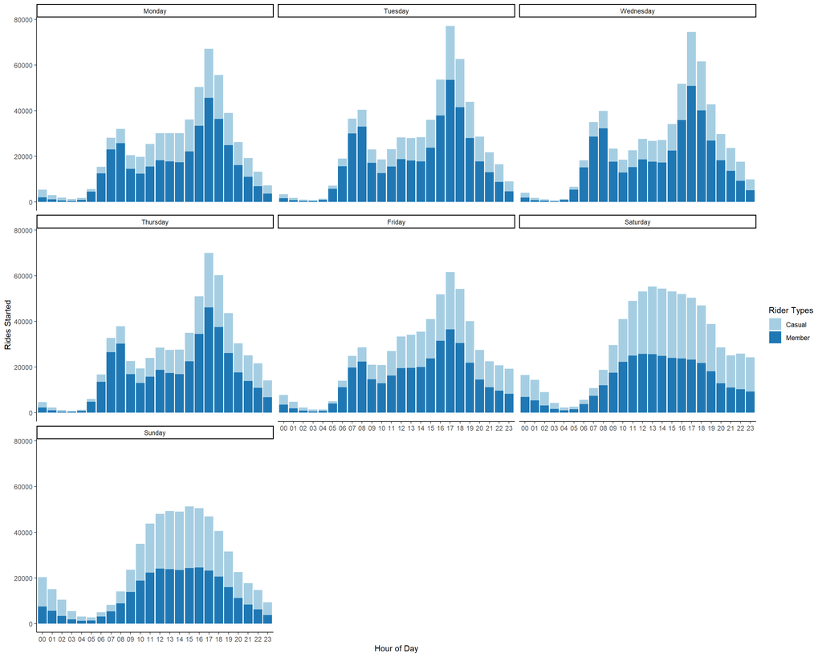

#### Trip length

Now that I understood seasonal and hourly rider habits, I wanted to better understand trip duration. I split the data by rider type and displayed it in box plots. These plots showed a more detailed view of what the summary above hinted at.

Since the data is split by member and casual rider, I was able to see that casual riders ride for longer on average and their ride times are more varied then members. The average ride time for casual riders floats somewhere between 10 and 15 minutes. Members tend towards shorter rides, with an average in the 8 to 10 minute range. Their ride times also cover a narrower range between the first and third quartile, indicating more consistent trip duration.

From this data I can build on some past observations. The narrow range and short average of member ride times indicated to me that members primarily use their bike rides for work or other task-oriented outings, as opposed to the leisure use by casual riders. Both groups see their highest ride times and greatest duration range on the weekends, which correlates with the increase use during that time.

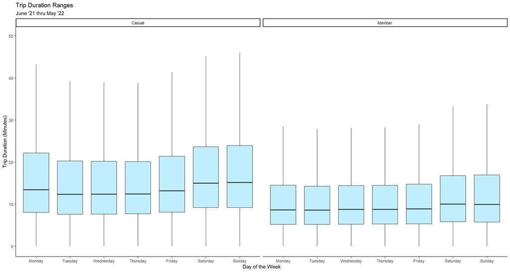

#### Hourly Ride Duration

I next split out hourly duration box plots for each day, divided by casual and member status. In this data we can further see the consistent nature of member trip duration, and the wider variety of trip duration among casual riders. I also saw that casual rider trip duration fluctuates greatly through out the day, where member rides hold steady around 8-10 minutes.

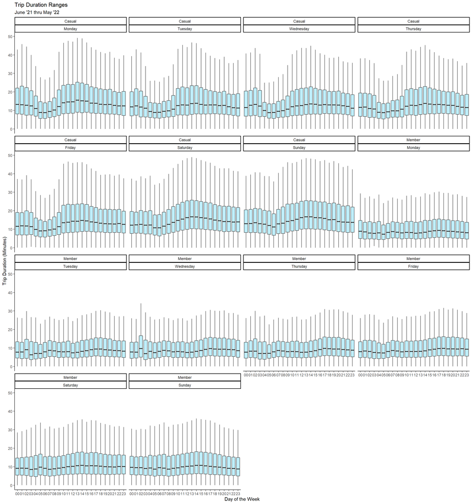

### Act

With the data now cleaned and processed, I have enough information to return to the original business task: **determine how annual members and casual riders use Cyclistic bikes differently, for the purpose of designing a new marketing strategy to convert casual riders into annual members.** To fulfill that task, I have to answer two questions: (1) How do annual members and casual riders use Cyclistic bikes differently? (2) How can casual riders be converted in to annual members?

#### How do annual members and casual riders use Cyclistic bikes differently?

Through my analysis I found that use of Cyclistic bikes breaksdown into three broad categories. **The first is as a commute option.** This is showcased by the ridership peaks around the beginning and end of the traditional work day, especially among members. **The second is as a convenient transit option.** The late night ridership among casual riders on weekends supports this category. As does the decrease in casual rider use during the winter months, when riding a bike becomes more difficult. **The third is as leisure.** I found this to be most on display during weekends, when casual and member ride counts were essentially equal. I also saw the increase in bike use among casual riders during the summer to be a supporting piece of evidence for this category.

I assert that member riders use Cyclistic bikes as a commuting tool and casual riders use them as a matter of convenience. Members ride more consistently, and trips on weekdays seem to be primarily focused around the 9 to 5 workday schedule. Casual rider trips are more varied and less attached to the 9 to 5 workday. Finally, both groups use Cyclistic bikes for what seems to be leisure or convenience on the weekends, a commonality that may offer other avenues for bringing in new members.

#### How can casual riders be converted in to annual members?

Converting casual riders to members can take many forms. I have listed a few possible options below. Each option could be implemented on its own or in concert with others.

##### Peak-pricing

Demand peaks at specific times of the day, and on specific days of the week. Introducing a peak-pricing model for the casual rider options of a single-ride or full-day pass would make the value proposition of a membership much more enticing. Annual memberships offer unlimited use of Cyclistic bikes for a flat fee, and thus would be immune from price fluctuations due to increased demand. Summer months, weekends, and work commute hours would be the best time to advertise memberships to casual riders. This may also be a time to offer sign-up discounts for memberships to make the choice to transition easier.

##### Monthly memberships

Introducing a monthly membership would provide an entry-point to casual riders who are hesitant about signing up for an annual service. If the price point is set correctly it will be above an annual membership, but low enough to offer savings to semi-regular casual riders. This gateway will serve to direct customers from casual rider status, to monthly membership, to annual membership, as they see the increased value each level provides.

##### Maximum ride times

During the cleaning process it was made evident that some bikes were taken out for extended periods of time (30+ days). Many of these trips were started by casual riders using one-time or all-day passes. If these outliers weren’t error but did in fact represent riders borrowing bikes for that amount of time, then it is a practice that must be ceased. Putting in place a max ride time for all riders would serve to prevent customers taking advantage of the rental system. It would help to keep the bike fleet at max capacity for both casual riders and members. Enforcement of this policy would come in the form of late return fees and potential use restriction for repeat offenders. There may also be an opportunity to convert these long-trip riders to members by presenting a discounted membership offer with their initial late notice, prior to any fees.

##### Promotion by Members

Cyclistic already has a large membership base that uses the service consistently and often. Offering those members some sort of reward for promoting the service to others would have a high cost/benefit ratio. This could include providing free passes for members to share with friends or family. It could also include a reward system if they refer people who become members. Benefits such as these could also be advertised directly to casual riders.

### Reflection

Completing this case study opened my eyes to the possibilities that R offers when working with large data pools. The final cleaned and merged data set had over 4 million objects, and R handled it easily. When that is combined with the built in plotting and markdown capabilities that R includes, it is hard to argue against it.

The Google Data Analytics Certificate course that this case study comes from essentially just throws you in the deep end for this final project, and I am grateful I had previous experience with writing code and finding support online. I am now much more confident in my abilities to clean and process data using R, Excel, and other tools, as well as getting plots to display data the way I imagine it. If I were to do this project over again, I would have a baseline of cleaning and plotting knowledge to lean on which would greatly improve my speed and efficiency.

#### For future projects I would like to work on the following, in no particular order:

- Gain a better understanding of gglot2 and other plotting tools.
- Learn methods for exporting data from R once it’s been cleaned and processed. I tried exporting a csv of the finished data but it went painfully slow. This forced me to move on, and I missed the opportunity to better understand the data through exploration of the location data.
- Streamline my cleaning process, and learn to better detect problems with my cleaning process.
- Learn to integrate R studio with other services, like Tableau.
- Try out Python to see how it compares to R for data analysis.

### Thank you for taking the time to review my first case study using R.